# Лабораторная работа No 6.

Тагиев Б. А.

Российский университет дружбы народов, Москва, Россия

14 октября 2023

## Цель работы

Развить навыки администрирования ОС Linux. Получить первое практическое знакомство с технологией SELinux.

# Выполнение лабораторной работы

## Подготовка лабораторного стенда

1. Установить `Apache2` при помощи `dnf`.

```
dnf install httpd
```

## Подготовка лабораторного стенда

2. В конфигурационном файле httpd.conf прописать параметр ServerName.

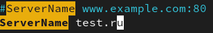

ServerName

## Подготовка лабораторного стенда

3. Отключить пакетный фильтр при помощи `iptables`.

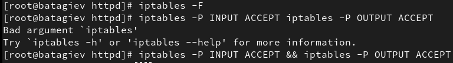

iptables

## Выполнение

1. Проверим правильность работы SELinux. Должен быть выставлен режим enforcing политики targeted.

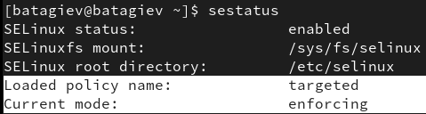

sestatus

## Выполнение

2. Запустим Apache веб-сервер.

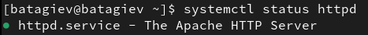

httpd

## Выполнение

3. В списке процессов найдем httpd.

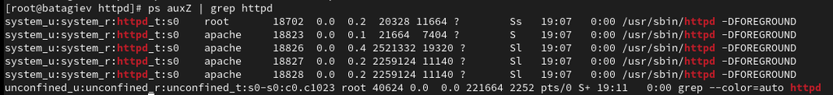

Контекст безопасности

## Выполнение

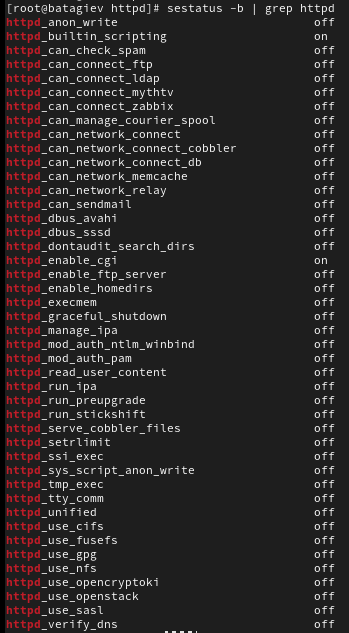

переключатели SELinux

4. Посмотрим текущее состояние переключателей SELinux для Apache2.

## Выполнение

5. Также посмотрим текущую статистику по политике.

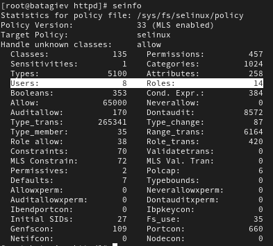

Статистика по политике

## Выполнение

6. Посмотрим текущий контекст безопасности для файлов и поддиректорий в директории `/var/www`.
- Установлен контекст `httpd_sys_script_exec_t` для cgi-скриптов, чтобы был разрешен им доступ ко всем sys-типам.
- Установлен контекст `httpd_sys_content_t` для содержимого, которое должно быть доступно для всех скриптов httpd и для самого демона.

## Выполнение

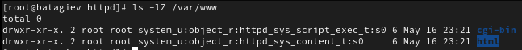

Контекст безопасности

## Выполнение

7. В директории `/var/www/html` пусто.

## Выполнение

8. В директории `/var/www/html` создавать папки может только root.

## Выполнение

9. Создадим файл `/var/www/html/test.html`.

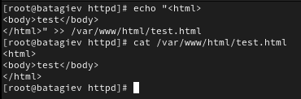

test.html

## Выполнение

10. Проверим контекст созданного нами файла.

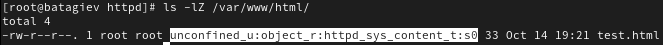

test.html

## Выполнение

11. Перейдем в браузер и в нем проверим доступность данного файла.

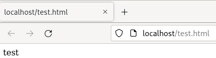

Проверка

## Выполнение

12. Изменим конекст файла, чтобы Apache не смог получить доступ.

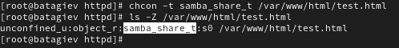

test.html

## Выполнение

13. Проверим, что доступ к файлу стал не доступен.

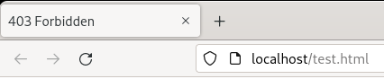

Проверка

## Выполнение

Также проверим audit.log.

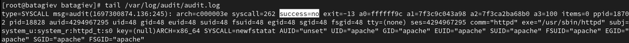

/var/log/audit/audit.log

## Выполнение

15. Поменяем порт, на котором работает Apache.

## Выполнение

16. Перезапустим веб-сервер.

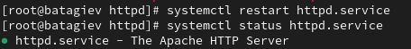

Перезапуск

## Выполнение

17. В логах наблюдаем запуск сервера на 81 порту.

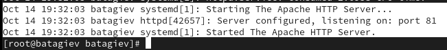

/var/log/messages

## Выполнение

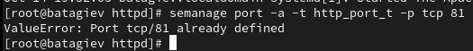

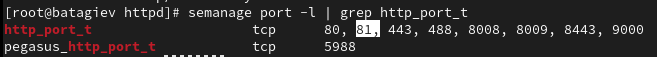

Проверка

## Выполнение

19. Ввернем контекст файлу `test.html`.
20. Удалим привязку порта.
21. Удалим файл `test.html`.

## Выводы

В результате выполнения работы я выполнил цели работы.